# Сессия1.

В данной сессии нам необходимо предобработать данные, визуализировать. Подготовить обучающую и тестовую выборку, создать частотный мешок сайтов и подготовить отчет

## 1.1 Подготовка тестовой и обучающей выборки.

В данном задании нам необходимо подготовить данные для дальнейшего анализа и построения прогнозных моделей. После этого необходимо выполнить загрузку всех данных. Данные должны быть очищены

Для того чтобы загрузить наши данные, будем использовать следющие библиотеки

```python
#import libs
import pandas as pd
```

Для начала посмотрим на сами данные

```python
df_train = pd.read_csv("train_ses.csv")
df_test = pd.read_csv("test_ses.csv")
```

Загрузим также `pkl` файл

```python
site = pd.read_pickle("site.pkl")
```

Для начала посмотрим на `train_ses.csv`

```python
df_train.head()
```

|  | session_id | site1 | time1 | site2 | time2 | site3 | time3 | site4 | time4 | site5 | ... | time6 | site7 | time7 | site8 | time8 | site9 | time9 | site10 | time10 | target |
| --- | --- | --- | --- | --- | --- | --- | --- | --- | --- | --- | --- | --- | --- | --- | --- | --- | --- | --- | --- | --- | --- |
| 0 | 1 | 718 | 2014-02-20 10:02:45 | NaN | NaN | NaN | NaN | NaN | NaN | NaN | ... | NaN | NaN | NaN | NaN | NaN | NaN | NaN | NaN | NaN | 0 |
| 1 | 2 | 890 | 2014-02-22 11:19:50 | 941.0 | 2014-02-22 11:19:50 | 3847.0 | 2014-02-22 11:19:51 | 941.0 | 2014-02-22 11:19:51 | 942.0 | ... | 2014-02-22 11:19:51 | 3847.0 | 2014-02-22 11:19:52 | 3846.0 | 2014-02-22 11:19:52 | 1516.0 | 2014-02-22 11:20:15 | 1518.0 | 2014-02-22 11:20:16 | 0 |
| 2 | 3 | 14769 | 2013-12-16 16:40:17 | 39.0 | 2013-12-16 16:40:18 | 14768.0 | 2013-12-16 16:40:19 | 14769.0 | 2013-12-16 16:40:19 | 37.0 | ... | 2013-12-16 16:40:19 | 14768.0 | 2013-12-16 16:40:20 | 14768.0 | 2013-12-16 16:40:21 | 14768.0 | 2013-12-16 16:40:22 | 14768.0 | 2013-12-16 16:40:24 | 0 |
| 3 | 4 | 782 | 2014-03-28 10:52:12 | 782.0 | 2014-03-28 10:52:42 | 782.0 | 2014-03-28 10:53:12 | 782.0 | 2014-03-28 10:53:42 | 782.0 | ... | 2014-03-28 10:54:42 | 782.0 | 2014-03-28 10:55:12 | 782.0 | 2014-03-28 10:55:42 | 782.0 | 2014-03-28 10:56:12 | 782.0 | 2014-03-28 10:56:42 | 0 |
| 4 | 5 | 22 | 2014-02-28 10:53:05 | 177.0 | 2014-02-28 10:55:22 | 175.0 | 2014-02-28 10:55:22 | 178.0 | 2014-02-28 10:55:23 | 177.0 | ... | 2014-02-28 10:55:59 | 175.0 | 2014-02-28 10:55:59 | 177.0 | 2014-02-28 10:55:59 | 177.0 | 2014-02-28 10:57:06 | 178.0 | 2014-02-28 10:57:11 | 0 |

5 rows × 22 columns

Далее посмотрим на `test_ses.csv`

```python
df_test.head()
```

|  | session_id | site1 | time1 | site2 | time2 | site3 | time3 | site4 | time4 | site5 | ... | site6 | time6 | site7 | time7 | site8 | time8 | site9 | time9 | site10 | time10 |
| --- | --- | --- | --- | --- | --- | --- | --- | --- | --- | --- | --- | --- | --- | --- | --- | --- | --- | --- | --- | --- | --- |
| 0 | 1 | 29 | 2014-10-04 11:19:53 | 35.0 | 2014-10-04 11:19:53 | 22.0 | 2014-10-04 11:19:54 | 321.0 | 2014-10-04 11:19:54 | 23.0 | ... | 2211.0 | 2014-10-04 11:19:54 | 6730.0 | 2014-10-04 11:19:54 | 21.0 | 2014-10-04 11:19:54 | 44582.0 | 2014-10-04 11:20:00 | 15336.0 | 2014-10-04 11:20:00 |
| 1 | 2 | 782 | 2014-07-03 11:00:28 | 782.0 | 2014-07-03 11:00:53 | 782.0 | 2014-07-03 11:00:58 | 782.0 | 2014-07-03 11:01:06 | 782.0 | ... | 782.0 | 2014-07-03 11:01:10 | 782.0 | 2014-07-03 11:01:23 | 782.0 | 2014-07-03 11:01:29 | 782.0 | 2014-07-03 11:01:30 | 782.0 | 2014-07-03 11:01:53 |
| 2 | 3 | 55 | 2014-12-05 15:55:12 | 55.0 | 2014-12-05 15:55:13 | 55.0 | 2014-12-05 15:55:14 | 55.0 | 2014-12-05 15:56:15 | 55.0 | ... | 55.0 | 2014-12-05 15:56:17 | 55.0 | 2014-12-05 15:56:18 | 55.0 | 2014-12-05 15:56:19 | 1445.0 | 2014-12-05 15:56:33 | 1445.0 | 2014-12-05 15:56:36 |
| 3 | 4 | 1023 | 2014-11-04 10:03:19 | 1022.0 | 2014-11-04 10:03:19 | 50.0 | 2014-11-04 10:03:20 | 222.0 | 2014-11-04 10:03:21 | 202.0 | ... | 3374.0 | 2014-11-04 10:03:22 | 50.0 | 2014-11-04 10:03:22 | 48.0 | 2014-11-04 10:03:22 | 48.0 | 2014-11-04 10:03:23 | 3374.0 | 2014-11-04 10:03:23 |
| 4 | 5 | 301 | 2014-05-16 15:05:31 | 301.0 | 2014-05-16 15:05:32 | 301.0 | 2014-05-16 15:05:33 | 66.0 | 2014-05-16 15:05:39 | 67.0 | ... | 69.0 | 2014-05-16 15:05:40 | 70.0 | 2014-05-16 15:05:40 | 68.0 | 2014-05-16 15:05:40 | 71.0 | 2014-05-16 15:05:40 | 167.0 | 2014-05-16 15:05:44 |

5 rows × 21 columns

```python
site
```

[output not shown]

[output cut: 946 more lines]

[output not shown]

```python
df_test.info()
```

```
<class 'pandas.core.frame.DataFrame'>
RangeIndex: 82797 entries, 0 to 82796
Data columns (total 21 columns):
 #   Column      Non-Null Count  Dtype
---  ------      --------------  -----
 0   session_id  82797 non-null  int64
 1   site1       82797 non-null  int64
 2   time1       82797 non-null  object
 3   site2       81308 non-null  float64
 4   time2       81308 non-null  object
 5   site3       80075 non-null  float64
 6   time3       80075 non-null  object
 7   site4       79182 non-null  float64
 8   time4       79182 non-null  object
 9   site5       78341 non-null  float64
 10  time5       78341 non-null  object
 11  site6       77566 non-null  float64
 12  time6       77566 non-null  object
 13  site7       76840 non-null  float64
 14  time7       76840 non-null  object
 15  site8       76151 non-null  float64
 16  time8       76151 non-null  object
 17  site9       75484 non-null  float64
 18  time9       75484 non-null  object
 19  site10      74806 non-null  float64
 20  time10      74806 non-null  object
dtypes: float64(9), int64(2), object(10)
memory usage: 13.3+ MB
```

```python
df_train.info()
```

```
<class 'pandas.core.frame.DataFrame'>
RangeIndex: 253561 entries, 0 to 253560
Data columns (total 22 columns):
 #   Column      Non-Null Count   Dtype
---  ------      --------------   -----
 0   session_id  253561 non-null  int64
 1   site1       253561 non-null  int64
 2   time1       253561 non-null  object
 3   site2       250098 non-null  float64
 4   time2       250098 non-null  object
 5   site3       246919 non-null  float64
 6   time3       246919 non-null  object
 7   site4       244321 non-null  float64
 8   time4       244321 non-null  object
 9   site5       241829 non-null  float64
 10  time5       241829 non-null  object
 11  site6       239495 non-null  float64
 12  time6       239495 non-null  object
 13  site7       237297 non-null  float64
 14  time7       237297 non-null  object
 15  site8       235224 non-null  float64
 16  time8       235224 non-null  object
 17  site9       233084 non-null  float64
 18  time9       233084 non-null  object
 19  site10      231052 non-null  float64
 20  time10      231052 non-null  object
 21  target      253561 non-null  int64
dtypes: float64(9), int64(3), object(10)
memory usage: 42.6+ MB
```

```python
#Очистка от NaN значений для тренировочной выборки
df_train = df_train.fillna(0)
df_train = df_train.reset_index(drop = True)
#Очистка от NaN значений для тестовой выборки
df_test = df_test.fillna(0)
df_test = df_test.reset_index(drop = True)
```

```python
df_train.head()
```

|  | session_id | site1 | time1 | site2 | time2 | site3 | time3 | site4 | time4 | site5 | ... | time6 | site7 | time7 | site8 | time8 | site9 | time9 | site10 | time10 | target |
| --- | --- | --- | --- | --- | --- | --- | --- | --- | --- | --- | --- | --- | --- | --- | --- | --- | --- | --- | --- | --- | --- |
| 0 | 1 | 718 | 2014-02-20 10:02:45 | 0.0 | 0 | 0.0 | 0 | 0.0 | 0 | 0.0 | ... | 0 | 0.0 | 0 | 0.0 | 0 | 0.0 | 0 | 0.0 | 0 | 0 |
| 1 | 2 | 890 | 2014-02-22 11:19:50 | 941.0 | 2014-02-22 11:19:50 | 3847.0 | 2014-02-22 11:19:51 | 941.0 | 2014-02-22 11:19:51 | 942.0 | ... | 2014-02-22 11:19:51 | 3847.0 | 2014-02-22 11:19:52 | 3846.0 | 2014-02-22 11:19:52 | 1516.0 | 2014-02-22 11:20:15 | 1518.0 | 2014-02-22 11:20:16 | 0 |
| 2 | 3 | 14769 | 2013-12-16 16:40:17 | 39.0 | 2013-12-16 16:40:18 | 14768.0 | 2013-12-16 16:40:19 | 14769.0 | 2013-12-16 16:40:19 | 37.0 | ... | 2013-12-16 16:40:19 | 14768.0 | 2013-12-16 16:40:20 | 14768.0 | 2013-12-16 16:40:21 | 14768.0 | 2013-12-16 16:40:22 | 14768.0 | 2013-12-16 16:40:24 | 0 |
| 3 | 4 | 782 | 2014-03-28 10:52:12 | 782.0 | 2014-03-28 10:52:42 | 782.0 | 2014-03-28 10:53:12 | 782.0 | 2014-03-28 10:53:42 | 782.0 | ... | 2014-03-28 10:54:42 | 782.0 | 2014-03-28 10:55:12 | 782.0 | 2014-03-28 10:55:42 | 782.0 | 2014-03-28 10:56:12 | 782.0 | 2014-03-28 10:56:42 | 0 |
| 4 | 5 | 22 | 2014-02-28 10:53:05 | 177.0 | 2014-02-28 10:55:22 | 175.0 | 2014-02-28 10:55:22 | 178.0 | 2014-02-28 10:55:23 | 177.0 | ... | 2014-02-28 10:55:59 | 175.0 | 2014-02-28 10:55:59 | 177.0 | 2014-02-28 10:55:59 | 177.0 | 2014-02-28 10:57:06 | 178.0 | 2014-02-28 10:57:11 | 0 |

5 rows × 22 columns

```python
df_train.info()
```

```
<class 'pandas.core.frame.DataFrame'>
RangeIndex: 253561 entries, 0 to 253560
Data columns (total 22 columns):
 #   Column      Non-Null Count   Dtype
---  ------      --------------   -----
 0   session_id  253561 non-null  int64
 1   site1       253561 non-null  int64
 2   time1       253561 non-null  object
 3   site2       253561 non-null  float64
 4   time2       253561 non-null  object
 5   site3       253561 non-null  float64
 6   time3       253561 non-null  object
 7   site4       253561 non-null  float64
 8   time4       253561 non-null  object
 9   site5       253561 non-null  float64
 10  time5       253561 non-null  object
 11  site6       253561 non-null  float64
 12  time6       253561 non-null  object
 13  site7       253561 non-null  float64
 14  time7       253561 non-null  object
 15  site8       253561 non-null  float64
 16  time8       253561 non-null  object
 17  site9       253561 non-null  float64
 18  time9       253561 non-null  object
 19  site10      253561 non-null  float64
 20  time10      253561 non-null  object
 21  target      253561 non-null  int64
dtypes: float64(9), int64(3), object(10)
memory usage: 42.6+ MB
```

Далее нам необходимо привести времнянные ряды к типу данных `datetime` и привести данные по сессиям к `int64` вместо `float64`

- Создадим 2 словаря с типами данных для каждой переменной
- После чего преобразуем тип с помощью метода `.astype()`

```python
#datetime
td = {"time1": 'datetime64',
      "time2": 'datetime64',
      "time3": 'datetime64',
      "time4": 'datetime64',
      "time5": 'datetime64',
      "time6": 'datetime64',
      "time7": 'datetime64',
      "time8": 'datetime64',
      "time9": 'datetime64',
      "time10": 'datetime64'}
#int64
sd = {"site1": 'int64',
      "site2": 'int64',
      "site3": 'int64',
      "site4": 'int64',
      "site5": 'int64',
      "site6": 'int64',
      "site7": 'int64',
      "site8": 'int64',
      "site9": 'int64',
      "site10": 'int64'}
#do datetime astype
df_train = df_train.astype(td)
df_test = df_test.astype(td)
#do int64 astype
df_train = df_train.astype(sd)
df_test = df_test.astype(sd)
```

```python
df_test.info()
```

```
<class 'pandas.core.frame.DataFrame'>
RangeIndex: 82797 entries, 0 to 82796
Data columns (total 21 columns):
 #   Column      Non-Null Count  Dtype
---  ------      --------------  -----
 0   session_id  82797 non-null  int64
 1   site1       82797 non-null  int64
 2   time1       82797 non-null  datetime64[ns]
 3   site2       82797 non-null  int64
 4   time2       82797 non-null  datetime64[ns]
 5   site3       82797 non-null  int64
 6   time3       82797 non-null  datetime64[ns]
 7   site4       82797 non-null  int64
 8   time4       82797 non-null  datetime64[ns]
 9   site5       82797 non-null  int64
 10  time5       82797 non-null  datetime64[ns]
 11  site6       82797 non-null  int64
 12  time6       82797 non-null  datetime64[ns]
 13  site7       82797 non-null  int64
 14  time7       82797 non-null  datetime64[ns]
 15  site8       82797 non-null  int64
 16  time8       82797 non-null  datetime64[ns]
 17  site9       82797 non-null  int64
 18  time9       82797 non-null  datetime64[ns]
 19  site10      82797 non-null  int64
 20  time10      82797 non-null  datetime64[ns]
dtypes: datetime64[ns](10), int64(11)
memory usage: 13.3 MB
```

```python
df_test
```

|  | session_id | site1 | time1 | site2 | time2 | site3 | time3 | site4 | time4 | site5 | ... | site6 | time6 | site7 | time7 | site8 | time8 | site9 | time9 | site10 | time10 |
| --- | --- | --- | --- | --- | --- | --- | --- | --- | --- | --- | --- | --- | --- | --- | --- | --- | --- | --- | --- | --- | --- |
| 0 | 1 | 29 | 2014-10-04 11:19:53 | 35 | 2014-10-04 11:19:53 | 22 | 2014-10-04 11:19:54 | 321 | 2014-10-04 11:19:54 | 23 | ... | 2211 | 2014-10-04 11:19:54 | 6730 | 2014-10-04 11:19:54 | 21 | 2014-10-04 11:19:54 | 44582 | 2014-10-04 11:20:00 | 15336 | 2014-10-04 11:20:00 |
| 1 | 2 | 782 | 2014-07-03 11:00:28 | 782 | 2014-07-03 11:00:53 | 782 | 2014-07-03 11:00:58 | 782 | 2014-07-03 11:01:06 | 782 | ... | 782 | 2014-07-03 11:01:10 | 782 | 2014-07-03 11:01:23 | 782 | 2014-07-03 11:01:29 | 782 | 2014-07-03 11:01:30 | 782 | 2014-07-03 11:01:53 |
| 2 | 3 | 55 | 2014-12-05 15:55:12 | 55 | 2014-12-05 15:55:13 | 55 | 2014-12-05 15:55:14 | 55 | 2014-12-05 15:56:15 | 55 | ... | 55 | 2014-12-05 15:56:17 | 55 | 2014-12-05 15:56:18 | 55 | 2014-12-05 15:56:19 | 1445 | 2014-12-05 15:56:33 | 1445 | 2014-12-05 15:56:36 |
| 3 | 4 | 1023 | 2014-11-04 10:03:19 | 1022 | 2014-11-04 10:03:19 | 50 | 2014-11-04 10:03:20 | 222 | 2014-11-04 10:03:21 | 202 | ... | 3374 | 2014-11-04 10:03:22 | 50 | 2014-11-04 10:03:22 | 48 | 2014-11-04 10:03:22 | 48 | 2014-11-04 10:03:23 | 3374 | 2014-11-04 10:03:23 |
| 4 | 5 | 301 | 2014-05-16 15:05:31 | 301 | 2014-05-16 15:05:32 | 301 | 2014-05-16 15:05:33 | 66 | 2014-05-16 15:05:39 | 67 | ... | 69 | 2014-05-16 15:05:40 | 70 | 2014-05-16 15:05:40 | 68 | 2014-05-16 15:05:40 | 71 | 2014-05-16 15:05:40 | 167 | 2014-05-16 15:05:44 |
| ... | ... | ... | ... | ... | ... | ... | ... | ... | ... | ... | ... | ... | ... | ... | ... | ... | ... | ... | ... | ... | ... |
| 82792 | 82793 | 812 | 2014-10-02 18:20:09 | 1039 | 2014-10-02 18:20:09 | 676 | 2014-10-02 18:20:09 | 0 | 1970-01-01 00:00:00 | 0 | ... | 0 | 1970-01-01 00:00:00 | 0 | 1970-01-01 00:00:00 | 0 | 1970-01-01 00:00:00 | 0 | 1970-01-01 00:00:00 | 0 | 1970-01-01 00:00:00 |
| 82793 | 82794 | 300 | 2014-05-26 14:16:40 | 302 | 2014-05-26 14:16:41 | 302 | 2014-05-26 14:16:44 | 300 | 2014-05-26 14:16:44 | 300 | ... | 1222 | 2014-05-26 14:17:19 | 302 | 2014-05-26 14:17:19 | 1218 | 2014-05-26 14:17:19 | 1221 | 2014-05-26 14:17:19 | 1216 | 2014-05-26 14:17:19 |
| 82794 | 82795 | 29 | 2014-05-02 11:21:56 | 33 | 2014-05-02 11:21:56 | 35 | 2014-05-02 11:21:56 | 22 | 2014-05-02 11:22:03 | 37 | ... | 6779 | 2014-05-02 11:22:03 | 30 | 2014-05-02 11:22:03 | 21 | 2014-05-02 11:22:04 | 23 | 2014-05-02 11:22:04 | 6780 | 2014-05-02 11:22:04 |
| 82795 | 82796 | 5828 | 2014-05-03 10:05:25 | 23 | 2014-05-03 10:05:27 | 21 | 2014-05-03 10:05:27 | 804 | 2014-05-03 10:05:27 | 21 | ... | 3350 | 2014-05-03 10:05:37 | 23 | 2014-05-03 10:05:37 | 894 | 2014-05-03 10:05:38 | 21 | 2014-05-03 10:05:38 | 961 | 2014-05-03 10:05:38 |
| 82796 | 82797 | 21 | 2014-11-02 10:46:57 | 1098 | 2014-11-02 10:46:57 | 1098 | 2014-11-02 10:46:58 | 1098 | 2014-11-02 10:47:12 | 1098 | ... | 1098 | 2014-11-02 10:47:14 | 1098 | 2014-11-02 10:47:15 | 1098 | 2014-11-02 10:47:18 | 1098 | 2014-11-02 10:47:42 | 1098 | 2014-11-02 10:47:47 |

82797 rows × 21 columns

Добавим наш словарь сайтов в отдельный датафрейм

```python
df_sites = pd.DataFrame(data = site.values(), index = site.keys(), columns = ["site_id"])
```

```python
df_sites
```

|  | site_id |
| --- | --- |
| www.abmecatronique.com | 25075 |
| groups.live.com | 13997 |
| majeureliguefootball.wordpress.com | 42436 |
| cdt46.media.tourinsoft.eu | 30911 |
| www.hdwallpapers.eu | 8104 |
| ... | ... |
| i1-js-14-3-01-11074-747051290-i.init.cedexis-radar.net | 29738 |
| i1-js-14-3-01-12434-548464295-i.init.cedexis-radar.net | 40794 |
| embed.api.tv | 10939 |
| n-tennis.fr | 40028 |
| posters.tripican.com | 43410 |

48371 rows × 1 columns

```python
#drop for train
df_train = df_train.drop(columns = "session_id", axis = 1)
#drop for test
df_test = df_test.drop(columns = "session_id", axis = 1)
```

Далее сохраним наши данные в `csv` формат

```python
print("Идет сохранение данных")
df_train.to_csv("train_clean.csv")
df_test.to_csv("test_clean.csv")
df_sites.to_csv("sites_df.csv")
print("Данные сохранены")
```

```
Идет сохранение данных
Данные сохранены
```

### Итог 1.1.

1. Данные очищены от NaN значений
2. Преобразованы типы данных к нужному формату
3. Итоговые выборки сохранены

## 1.2 Работа с разреженным форматом данных

В данном задании нам необходимо сформировать мешок сайтов, то есть необходимо создать новые таблицы, в которых строкам будут соответствовать сессии из 10 сайтов, а столбцам индексы

```python
S = ["site" + str(i) for i in range(1, 11)]
dict_train = {}
for i in range(len(df_train)):
    d = df_train.iloc[i][S].value_counts().to_json()
    dict_train[i] = d
```

```python
S = ["site" + str(i) for i in range(1, 11)]
dict_test = {}
for i in range(len(df_test)):
    d = df_test.iloc[i][S].value_counts().to_json()
    dict_test[i] = d
```

```python
#сохраняем тренировочную выборку
import pickle
fileName = "dicTrain.pkl"
print("Сохраняем частотный словарь для тренировочной выборки")
with open(fileName, "wb") as fileTrain:
    pickle.dump(dict_train, fileTrain)
print("Словарь сохранен!")
```

```
Сохраняем частотный словарь для тренировочной выборки
Словарь сохранен!
```

```python
#сохраняем тренировочную выборку
import pickle
fileName = "dicTest.pkl"
print("Сохраняем частотный словарь для тестовой выборки")
with open(fileName, "wb") as fileTrain:
    pickle.dump(dict_test, fileTrain)
print("Словарь сохранен!")
```

```
Сохраняем частотный словарь для тестовой выборки
Словарь сохранен!
```

## Итог 1.2

- Частотный словарь сформирован

## 1.3 Визуальный анализ данных

Используя программные средства, необходимо визуализировать зависимости данных

В качестве первого метода будем использовать `countplot` чтобы посмотреть визуальное распределение нашего таргета

```python
import seaborn as sns
%matplotlib inline
import matplotlib.pyplot as plt
```

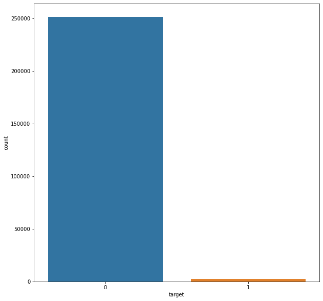

```python
#countplot
plt.figure(figsize = (10, 10))
sns.countplot(df_train["target"])
```

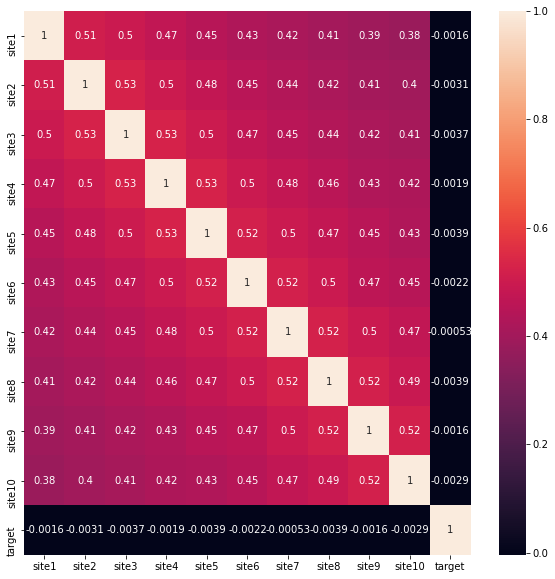

```python
#heatmap
plt.figure(figsize = (10, 10))
sns.heatmap(df_train.corr(), annot = True)
```

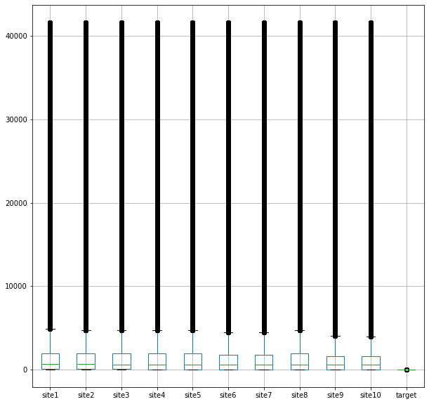

```python
#boxplot
df_train.boxplot(figsize = (10, 10))
```

## 1.4 Конструирование признаков(Feature Engineering)

В данном задании необходимо создать такую функцию которая будет добавлять в наши датафреймы новые признаки

```python
import datetime
```

```python
def new_features(df):
    df["ym"] = df.apply(lambda x: "".join(str(x["time1"])[:str(x["time1"]).rfind("-")].split("-")), axis=1)

    df["time_diff"] = df.apply(lambda x: (datetime.datetime.strptime(str(x["time10"]), '%Y-%m-%d %H:%M:%S') -
 datetime.datetime.strptime(str(x["time1"]), '%Y-%m-%d %H:%M:%S')).total_seconds(), axis=1)

    df["max_repeat"] = df[["site1","site2","site3","site4","site5","site6","site7","site8","site9","site10"]].apply(lambda x: x.value_counts().max(), axis=1)

    df = df.astype({"ym":"int64"})
    return df
```

```python
df_train = new_features(df_train)
```

```python
df_test = new_features(df_test)
```

```python
df_train.head()
```

[output not shown]

5 rows × 25 columns

```python
df_test.head()
```

[output not shown]

5 rows × 24 columns

## Итог 1.4

- добавлены новые признаки, а именно:
- разделение месяца и года
- добавлен признак сколько человек времени на сайте
- признак максимального повторения

# Заключение

1. Тестовая и обучающая выборки подготовленны и сохранены в `csv` формате. Отражено в отчете
2. Словари сайтов сформированны
3. Данные провизуализированны
4. Новые признаки сконструированны
5. Отчет подготовлен